# lme4 convergence warnings: troubleshooting

For large data sets and large, complex models (lots of random-effects parameters, or for GLMMs also lots of fixed-effect parameters), it is fairly common to get convergence warnings. (A lot of these were removed in version 1.1-7, but they still happen.) Here I’m going to brain-dump/show a variety of examples of tests that rule out various hypotheses about what’s causing the problem.

- check for singularity
- lower convergence tolerances/run longer
- restart from the ending parameters
- try other optimizers
- recompute gradient/Hessian more precisely
- consider absolute vs. scaled gradient

```r
library("lme4")
packageVersion("lme4")
```

```
## [1] '1.1.8'
```

```r
## but should work equivalently with 1.1-7 (latest CRAN version)
library("numDeriv")
library("RCurl") ## to source() from Github
library("ggplot2"); theme_set(theme_bw())
library("reshape2")
library("plyr")
library("RColorBrewer")
```

## Example

Example from [Stack Overflow](http://stackoverflow.com/questions/23478792/warning-messages-when-trying-to-run-glmer-in-r):

```r
source("SO_23478792_dat.R")
df$SUR.ID <- factor(df$SUR.ID)
df$replicate <- factor(df$replicate)
Rdet <- cbind(df$ValidDetections,df$FalseDetections)
Unit <- factor(1:length(df$ValidDetections))
```

```r
m1 <- glmer(Rdet ~ tm:Area + tm:c.distance +
            c.distance:Area + c.tm.depth:Area +
            c.receiver.depth:Area + c.temp:Area +
            c.wind:Area +
            c.tm.depth + c.receiver.depth +
            c.temp +c.wind + tm + c.distance + Area +
            replicate +
            (1|SUR.ID) + (1|Day) + (1|Unit) ,
            data = df, family = binomial(link=logit))
```

```
## Warning in checkConv(attr(opt, "derivs"), opt$par, ctrl =
## control$checkConv, : Model failed to converge with max|grad| = 1.52673
## (tol = 0.001, component 17)
```

```
## Warning in checkConv(attr(opt, "derivs"), opt$par, ctrl = control$checkConv, : Model is nearly unidentifiable: very large eigenvalue
##  - Rescale variables?;Model is nearly unidentifiable: large eigenvalue ratio
##  - Rescale variables?
```

Data set size:

```r
nrow(df)
```

```
## [1] 220
```

```r
length(getME(m1,"theta"))
```

```
## [1] 3
```

```r
length(fixef(m1))
```

```
## [1] 16
```

### Rescale and center continuous parameters

It doesn’t *necessarily* mess up the fit, but large differences in the scales of parameters often lead to problems (especially with calculating standard deviations of fixed effects); we might as well clean up this problem before we proceed:

```r
numcols <- grep("^c\\.",names(df))
dfs <- df
dfs[,numcols] <- scale(dfs[,numcols])
m1_sc <- update(m1,data=dfs)
```

```
## Warning in checkConv(attr(opt, "derivs"), opt$par, ctrl =
## control$checkConv, : Model failed to converge with max|grad| = 1.28888
## (tol = 0.001, component 19)
```

Gets rid of scaling warnings, but we still have a large relative gradient.

## Check singularity

If the fit is singular or near-singular, there might be a higher chance of a false positive (we’re not necessarily screening out gradient and Hessian checking on singular directions properly); a higher chance that the model has actually misconverged (because the optimization problem is difficult on the boundary); and a reasonable argument that the random effects model should be simplified.

```r
tt <- getME(m1_sc,"theta")
ll <- getME(m1_sc,"lower")
min(tt[ll==0])
```

```
## [1] 0.007956743
```

Not a problem in this case.

## Double-checking gradient calculations

Compare absolute and scaled gradient; compare gradient and Hessian with `numDeriv` equivalents.

We compute the gradient and Hessian in a quick-but-less-accurate way; we can use a more precise (but slower) algorithm implemented by the `numDeriv` package (Richardson extrapolation).

Extract pre-computed information:

```r
derivs1 <- m1_sc@optinfo$derivs
sc_grad1 <- with(derivs1,solve(Hessian,gradient))
max(abs(sc_grad1))
```

```
## [1] 1.288884
```

One general problem is that large *scaled* gradients are often associated with small *absolute* gradients: we might decide that we’re more interested in testing the (parallel) minimum of these two quantities:

```r
max(pmin(abs(sc_grad1),abs(derivs1$gradient)))
```

```
## [1] 0.07784106
```

This is a lot smaller, although still larger than the tolerance we typically set (0.001).

What if we redo the calculations with `numDeriv`?

```r
dd <- update(m1_sc,devFunOnly=TRUE)
pars <- unlist(getME(m1_sc,c("theta","fixef")))
grad2 <- grad(dd,pars)
hess2 <- hessian(dd,pars)
sc_grad2 <- solve(hess2,grad2)
max(pmin(abs(sc_grad2),abs(grad2)))
```

```
## [1] 0.07784101
```

Not particularly different, in this case.

## Restart

Try restarting from previous fit … restart didn’t converge in 10000 evals, so bumped up max number of iterations.

```r
ss <- getME(m1_sc,c("theta","fixef"))
m2 <- update(m1_sc,start=ss,control=glmerControl(optCtrl=list(maxfun=2e4)))
```

```
## Warning in checkConv(attr(opt, "derivs"), opt$par, ctrl =
## control$checkConv, : Model failed to converge with max|grad| = 1.11384
## (tol = 0.001, component 19)
```

Still have a problem.

## Try a different optimizer

Try `bobyqa` for both phases – current GLMM default is `bobyqa` for first phase, Nelder-Mead for second phase. We are thinking about changing the default to `nloptwrap`, which is generally much faster. As we’ll see below, `nloptwrap` would *not* help with the convergence warning in this case …

```r
m3 <- update(m1_sc,start=ss,control=glmerControl(optimizer="bobyqa",
                            optCtrl=list(maxfun=2e5)))
```

If we set the number of evaluations large enough so the optimization actually finishes, we do avoid the warning.

## Try lots of different optimizers

Use [this recipe](http://tonybreyal.wordpress.com/2011/11/24/source_https-sourcing-an-r-script-from-github/) to source the `allFit` script from Github (it’s also been incorporated into the `mixed` package):

```r
afurl <- "https://raw.githubusercontent.com/lme4/lme4/master/misc/issues/allFit.R"
eval(parse(text=getURL(afurl)))
aa <- allFit(m2)
```

```r
is.OK <- sapply(aa,is,"merMod")  ## nlopt NELDERMEAD failed, others succeeded
aa.OK <- aa[is.OK]
lapply(aa.OK,function(x) x@optinfo$conv$lme4$messages)
```

```
## $bobyqa.
## NULL
##
## $Nelder_Mead.
## [1] "Model failed to converge with max|grad| = 1.24692 (tol = 0.001, component 19)"
##
## $optimx.nlminb
## NULL
##
## $`optimx.L-BFGS-B`
## [1] "Model failed to converge with max|grad| = 1.01503 (tol = 0.001, component 19)"
##
## $nloptwrap.NLOPT_LN_NELDERMEAD
## [1] "Model failed to converge with max|grad| = 1.27814 (tol = 0.001, component 19)"
##
## $nloptwrap.NLOPT_LN_BOBYQA
## [1] "Model failed to converge with max|grad| = 1.27814 (tol = 0.001, component 19)"
```

All but `nlminb` and built-in `bobyqa` give convergence warnings.

## So what?

In this case, we can overcome the failure to converge by using a different optimizer. But how bad was the convergence failure, really, in this case? Should we have worried at all?

```r
(lliks <- sort(sapply(aa.OK,logLik)))
```

```
## nloptwrap.NLOPT_LN_NELDERMEAD     nloptwrap.NLOPT_LN_BOBYQA
##                     -107.1693                     -107.1693
##                  Nelder_Mead.               optimx.L-BFGS-B
##                     -107.1161                     -107.1130
##                       bobyqa.                 optimx.nlminb
##                     -107.1098                     -107.1098
```

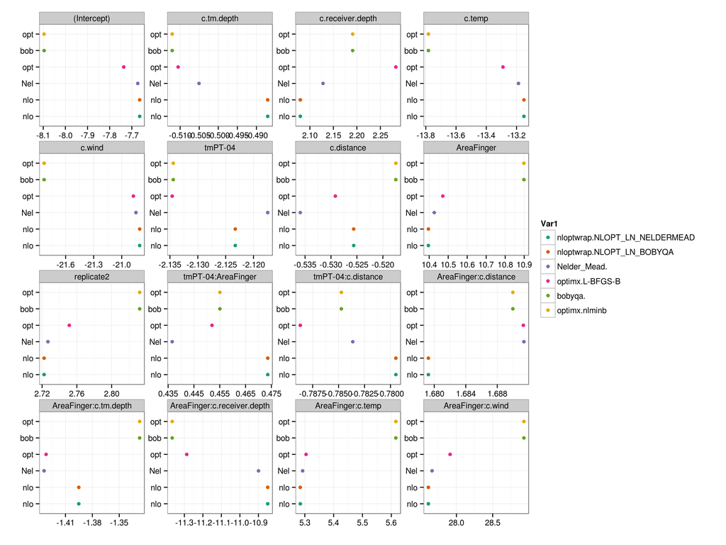

```r
aa.fixef <- t(sapply(aa.OK,fixef))
aa.fixef.m <- melt(aa.fixef)
models <- levels(aa.fixef.m$Var1)
ylabs <- substr(models,1,3)
aa.fixef.m <- transform(aa.fixef.m,Var1=factor(Var1,levels=names(lliks)))
(gplot1 <- ggplot(aa.fixef.m,aes(x=value,y=Var1,colour=Var1))+geom_point()+
     facet_wrap(~Var2,scale="free")+
         scale_colour_brewer(palette="Dark2")+
             scale_y_discrete(breaks=models,
                              labels=ylabs)+
                                  labs(x="",y=""))
```

Coefficients of variation of fixed-effect parameter estimates:

```r
summary(unlist(daply(aa.fixef.m,"Var2",summarise,sd(value)/abs(mean(value)))))
```

```
##     Min.  1st Qu.   Median     Mean  3rd Qu.     Max.
## 0.003513 0.017890 0.023470 0.021620 0.028250 0.036460
```

Not as interesting: all optimizers except N-M give very close to zero std.dev. for `Day` and `SUR.ID`

```r
aa.stddev <- t(sapply(aa.OK,function(x) sqrt(unlist(VarCorr(x)))))
print(aa.stddev,digits=3)
```

```
##                                Unit      Day   SUR.ID
## bobyqa.                       0.687 1.38e-08 3.73e-08
## Nelder_Mead.                  0.685 1.29e-03 2.98e-03
## optimx.nlminb                 0.687 0.00e+00 0.00e+00
## optimx.L-BFGS-B               0.686 0.00e+00 0.00e+00
## nloptwrap.NLOPT_LN_NELDERMEAD 0.592 2.66e-05 5.78e-04
## nloptwrap.NLOPT_LN_BOBYQA     0.592 2.66e-05 5.78e-04
```

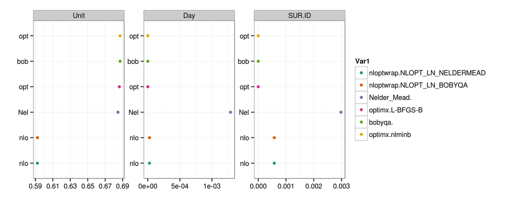

```r
aa.stddev.m <- melt(aa.stddev)
aa.stddev.m <- transform(aa.stddev.m,Var1=factor(Var1,levels=names(lliks)))
gplot1 %+% aa.stddev.m
```

I previously tried the `lme4.0` package for comparison, but I can’t quite get it to work for various reasons (apparent `knitr`/caching problems and/or `downdated X'X is not positive definite` errors): presented here without evaluation.

```r
library("lme4.0")
m5 <- glmer(Rdet ~ tm:Area + tm:c.distance +
            c.distance:Area + c.tm.depth:Area +
            c.receiver.depth:Area + c.temp:Area +
            c.wind:Area +
            c.tm.depth + c.receiver.depth +
            c.temp +c.wind + tm + c.distance + Area +
            replicate +
            (1|SUR.ID) + (1|Day) + (1|Unit) ,
            data = dfs, family = binomial(link=logit))
detach("package:lme4.0")
```